# Biodiversity of Loggerhead Sea Turtles

Jordan

2025-04-09

# Goals

Run an analysis on the within-sample biodiversity of the samples in our project.

## Outputs

1. Calculated biodiversity measures (Hill numbers) across every sample.
2. Figures to include in our scientific paper that visualize the data as it relates to the scientific question.
3. Statistical tests conveying the measured and quantified changes and patterns in biodiversity.

# Scientific Question

## Question & Hypotheses

How does microbial diversity of Loggerhead sea turtles change with age?

- *Null Hypothesis:* Microbial biodiversity (*e.g.* richness) does not vary with age.
- *Alternative Hypothesis:* Microbial biodiversity (*e.g.* richness) will increase as age increases. There is a positive relationship between richness and age.

## Field site background

The authors of this paper found Loggerhead sea turtles strained, injured, or unintentionally caught by fishermen in the Adriatic Sea area (one turtle named Angelo found in Tyrrhenian Sea), and transported them to recovery centres in Bari, Italy (Sea Turtle Clinic DVM University of Bari) and Pula (Aquarium Pula) Croatia where they received appropriate treatment.

## Timing of this script

```r
# What time did we start running this script?
start_time <- Sys.time()
```

## Set the seed

```r
set.seed(238428)
```

## Load Packages & Colors

```r
# install packages for stats
#install.packages("rstatix")
#install.packages("ggpubr")

pacman::p_load(tidyverse, devtools, patchwork, iNEXT, phyloseq,
               # packages for stats
               ggpubr, rstatix, install = FALSE)

# Load in colors for plotting
source("code/colors.R")
```

## Load in Data

```r
load("data/04_PhylogeneticTree/midpoint_rooted_physeq.RData")

# take a look at it!
midpoint_rooted_physeq
```

```
## phyloseq-class experiment-level object
## otu_table()   OTU Table:         [ 6632 taxa and 44 samples ]
## sample_data() Sample Data:       [ 44 samples by 38 sample variables ]
## tax_table()   Taxonomy Table:    [ 6632 taxa by 9 taxonomic ranks ]
## phy_tree()    Phylogenetic Tree: [ 6632 tips and 6631 internal nodes ]
```

```r
# Intuition check on seq depth
min(sample_sums(midpoint_rooted_physeq))
```

```
## [1] 1607
```

```r
# Make a metadata dataframe
metadata_df <-
  midpoint_rooted_physeq %>%
  sample_data() %>%
  data.frame()

# view of it
glimpse(metadata_df)
```

```
## Rows: 44
## Columns: 38
## $ TBSampleID                        <chr> "SC0064", "FW0064", "SC0073", "SO007…
## $ SamplingEvent                     <chr> "PMFTI0064", "PMFTI0064", "PMFTI0073…
## $ TurtleID                          <chr> "ID047", "ID047", "ID056", "ID056", …
## $ TurtleName                        <chr> "ZAL", "ZAL", "SAMBA", "SAMBA", "SAM…
## $ SampleSite                        <chr> "CLOACA", "TANK WATER", "CLOACA", "O…
## $ CarSampleID                       <chr> "TB115", "TB115", "TB117", "TB117", …
## $ SeqMethod                         <chr> "Illumina MiSeq", "Illumina MiSeq", …
## $ ForwardPrimer                     <chr> "CCTACGGGNGGCWGCAG", "CCTACGGGNGGCWG…
## $ ReversePrimer                     <chr> "GACTACHVGGGTATCTAATCC", "GACTACHVGG…
## $ Type                              <chr> "amplicon", "amplicon", "amplicon", …
## $ Gene                              <dbl> 16, 16, 16, 16, 16, 16, 16, 16, 16, …
## $ Region                            <chr> "V34", "V34", "V34", "V34", "V34", "…
## $ AdmissionDate                     <chr> "02.05.2019.", "02.05.2019.", "08.06…
```

[output cut: 25 more lines]

# Biodiversity Hill Numbers with iNEXT

## Hill Number Equation

Next, we will calculate the biodiversity with the [iNEXT package](https://besjournals.onlinelibrary.wiley.com/doi/full/10.1111/2041-210X.12613) package. iNEXT focuses on three measures of biodiversity via the Hill numbers. Hill numbers have the order q:

$${}^qD = \left( \sum_{i=1}^{S} p_i^q \right)^{1/(1 - q)}, \quad q \geq 0,
\quad q \neq 1.$$

But when *q = 1*, then the equation is:

$${}^1D = \lim_{q \to 1} {}^qD = \exp\left( - \sum_{i=1}^{S} p_i \log p_i
\right) = \exp(H_{sh}).$$

**Where:**

- ${}^qD$ is the *Hill number* or *diversity of order $q$*, a measure of species diversity.
- $q$ is the *order of diversity*, which determines how sensitive the measure is to species relative abundances:
  - $q = 0$: all species are weighted equally or **species richness**,
  - $q = 1$: corresponds to the exponential of **Shannon entropy**,
  - $q = 2$: corresponds to the **inverse of Simpson’s index**.
- $S$ is the *total number of species* in the community.
- $p_i$ is the *relative abundance* of species $i$, i.e., the proportion of individuals in the community belonging to species $i$.

### When $q = 0$: Counting *All* ASVs Equally

> *Species Richness* → ${}^0D$

Here, we ignore how common or rare each ASV is. Every ASV counts equally — even ones that appear just once.

Here, in the context of microbial communities, we are pondering: **“How many different ASVs are present?”** We do not weight them by abundance/evenness in any way. Rather, we focus on a binary measures of 0s and 1s that represent presence (1) and absence (0).

### When $q = 1$: Balancing Rarity and Commonness

> *Shannon Diversity* → ${}^1D$

Now we ask: **“How evenly are the ASVs distributed?”** Rare ASVs matter, but not as much as common ones.

### When $q = 2$: Focus on the Most Abundant ASVs

> *Simpson-like Diversity* → ${}^2D$

Now we modify our question to wonder: **How many ASVs dominate each sample?** Here, rare ASVs hardly matter.

Next, we will calculate the biodiversity with the [iNEXT package](https://besjournals.onlinelibrary.wiley.com/doi/full/10.1111/2041-210X.12613) package. iNEXT focuses on three measures of biodiversity via the Hill numbers. For each Hill NUmber [iNEXT package](https://besjournals.onlinelibrary.wiley.com/doi/full/10.1111/2041-210X.12613) uses the observed abundance of species within a sample to compute diversity estimates and the associated 95% confidence intervals for the following two types of rarefaction and extrapolation (R/E):

*An important note:* We’ll be using the size_based output. Our lab has previously been suspicious of the Asymptotic Estimator. Therefore we will use the size_based approach here, with the caveat that we will very rigorously confirm that we’ve approached saturation for all of our samples!

```r
# prepare the input data
# Species in rows and the samples in columns
iNEXT_input_df <-
  midpoint_rooted_physeq %>%
  otu_table() %>%
  data.frame()

# Inpect
dim(iNEXT_input_df)
```

```
## [1] 6632   44
```

```r
iNEXT_input_df[1:5, 1:5]
```

```
##          X16S0064C X16S0064W X16S0073C X16S0073O X16S0073W
## ASV_4279         0         0         0         0         0
## ASV_4660         0         0         0         0         0
## ASV_2990         0         0         0         0         0
## ASV_6253         0         3         0         0         0
## ASV_4167         0        18         0         0         0
```

```r
# Run iNEXT
# Remember to set the seed!
# ASVs in ROWs, samples in COLUMNS
#iNEXT_data <- iNEXT(iNEXT_input_df,
#                    q = c(0, 1, 2),
#                    datatype = "abundance")

# Inspect
#str(iNEXT_data)
#typeof(iNEXT_data)

# Save RData
#save(iNEXT_data,
#     file = "data/05_Biodiversity/iNEXT_data.RData")
```

```r
load("data/05_Biodiversity/iNEXT_data.RData")

# Inspect
str(iNEXT_data)
```

```
## List of 3
##  $ DataInfo:'data.frame':    44 obs. of  14 variables:
##   ..$ Assemblage: chr [1:44] "X16S0064C" "X16S0064W" "X16S0073C" "X16S0073O" ...
##   ..$ n         : num [1:44] 66771 63163 107267 73242 29488 ...
##   ..$ S.obs     : num [1:44] 362 601 220 280 499 142 216 110 580 177 ...
##   ..$ SC        : num [1:44] 1 1 1 1 1 ...
##   ..$ f1        : num [1:44] 2 3 1 1 2 0 2 0 0 0 ...
##   ..$ f2        : num [1:44] 8 14 2 2 24 2 2 2 8 0 ...
##   ..$ f3        : num [1:44] 18 37 5 6 28 5 2 4 11 6 ...
##   ..$ f4        : num [1:44] 11 30 4 4 26 4 7 1 21 3 ...
##   ..$ f5        : num [1:44] 14 36 5 7 45 2 4 4 13 2 ...
##   ..$ f6        : num [1:44] 11 37 2 1 31 0 5 3 9 4 ...
##   ..$ f7        : num [1:44] 10 26 5 5 28 3 4 7 16 1 ...
##   ..$ f8        : num [1:44] 11 30 8 6 25 1 6 3 15 3 ...
##   ..$ f9        : num [1:44] 15 34 5 4 22 2 6 2 14 0 ...
##   ..$ f10       : num [1:44] 12 18 7 5 12 7 5 3 11 3 ...
##  $ iNextEst:List of 2
##   ..$ size_based    :'data.frame':   5280 obs. of  10 variables:
##   .. ..$ Assemblage: chr [1:5280] "X16S0064C" "X16S0064C" "X16S0064C" "X16S0064C" ...
##   .. ..$ m         : num [1:5280] 1 3710 7419 11129 14838 ...
##   .. ..$ Method    : chr [1:5280] "Rarefaction" "Rarefaction" "Rarefaction" "Rarefaction" ...
##   .. ..$ Order.q   : num [1:5280] 0 0 0 0 0 0 0 0 0 0 ...
##   .. ..$ qD        : num [1:5280] 1 243 291 315 329 ...
##   .. ..$ qD.LCL    : num [1:5280] 1 240 288 312 326 ...
##   .. ..$ qD.UCL    : num [1:5280] 1 245 294 318 332 ...
##   .. ..$ SC        : num [1:5280] 0.0543 0.9803 0.9914 0.9951 0.9969 ...
##   .. ..$ SC.LCL    : num [1:5280] 0.0535 0.9799 0.9912 0.995 0.9968 ...
##   .. ..$ SC.UCL    : num [1:5280] 0.055 0.981 0.992 0.995 0.997 ...
##   ..$ coverage_based:'data.frame':   4263 obs. of  8 variables:
##   .. ..$ Assemblage: chr [1:4263] "X16S0064C" "X16S0064C" "X16S0064C" "X16S0064C" ...
##   .. ..$ SC        : num [1:4263] 0.0543 0.9803 0.9914 0.9951 0.9969 ...
##   .. ..$ m         : num [1:4263] 1 3710 7419 11129 14838 ...
##   .. ..$ Method    : chr [1:4263] "Rarefaction" "Rarefaction" "Rarefaction" "Rarefaction" ...
##   .. ..$ Order.q   : num [1:4263] 0 0 0 0 0 0 0 0 0 0 ...
##   .. ..$ qD        : num [1:4263] 1 243 291 315 329 ...
##   .. ..$ qD.LCL    : num [1:4263] 0.99 239.05 287.14 311.42 326.03 ...
##   .. ..$ qD.UCL    : num [1:4263] 1.01 246.32 294.28 318.05 332.2 ...
##  $ AsyEst  :'data.frame':    132 obs. of  7 variables:
##   ..$ Assemblage: chr [1:132] "X16S0064C" "X16S0064C" "X16S0064C" "X16S0064W" ...
##   ..$ Diversity : chr [1:132] "Species richness" "Shannon diversity" "Simpson diversity" "Species richness" ...
##   ..$ Observed  : num [1:132] 362 47.4 18.4 601 31.6 ...
##   ..$ Estimator : num [1:132] 362.2 47.5 18.4 601.3 31.8 ...
##   ..$ s.e.      : num [1:132] 2.871 0.324 0.127 3.659 0.347 ...
##   ..$ LCL       : num [1:132] 362 46.9 18.2 601 31.1 ...
##   ..$ UCL       : num [1:132] 367.9 48.1 18.7 608.5 32.5 ...
##  - attr(*, "class")= chr "iNEXT"
```

```r
typeof(iNEXT_data)
```

```
## [1] "list"
```

# Rarefaction Curves

## `ggiNEXT` Rarefaction Curves

```r
# Prepare Colors
color_df <-
  iNEXT_input_df %>%
  colnames() %>%
  data.frame()
# Check
head(color_df)
```

```
##           .
## 1 X16S0064C
## 2 X16S0064W
## 3 X16S0073C
## 4 X16S0073O
## 5 X16S0073W
## 6 X16S0074C
```

```r
# Rename the column
colnames(color_df)[1] <- "names"
# Check
head(color_df)
```

```
##       names
## 1 X16S0064C
## 2 X16S0064W
## 3 X16S0073C
## 4 X16S0073O
## 5 X16S0073W
## 6 X16S0074C
```

```r
# Make a helper dataframe for plotting with colors
iNEXT_color_df <-
  color_df %>%
  # Fix the names for merging
  mutate(names = gsub("X", "", names)) %>%
  # Merge with metadata
  left_join(metadata_df, by = "names") %>%
  # Merge with colors for plotting with ggiNEXT
  left_join(data.frame(AgeRange_colors = AgeRange_colors,
                       AgeRange = names(AgeRange_colors)),
            by = "AgeRange")

head(iNEXT_color_df)
```

```
##      names TBSampleID SamplingEvent TurtleID TurtleName SampleSite CarSampleID
## 1 16S0064C     SC0064     PMFTI0064    ID047        ZAL     CLOACA       TB115
## 2 16S0064W     FW0064     PMFTI0064    ID047        ZAL TANK WATER       TB115
## 3 16S0073C     SC0073     PMFTI0073    ID056      SAMBA     CLOACA       TB117
## 4 16S0073O     SO0073     PMFTI0073    ID056      SAMBA       ORAL       TB117
## 5 16S0073W     FW0073     PMFTI0073    ID056      SAMBA TANK WATER       TB117
## 6 16S0074C     SC0074     PMFTI0074    ID057     ANGELO     CLOACA        <NA>
##        SeqMethod     ForwardPrimer         ReversePrimer     Type Gene Region
## 1 Illumina MiSeq CCTACGGGNGGCWGCAG GACTACHVGGGTATCTAATCC amplicon   16    V34
## 2 Illumina MiSeq CCTACGGGNGGCWGCAG GACTACHVGGGTATCTAATCC amplicon   16    V34
## 3 Illumina MiSeq CCTACGGGNGGCWGCAG GACTACHVGGGTATCTAATCC amplicon   16    V34
## 4 Illumina MiSeq CCTACGGGNGGCWGCAG GACTACHVGGGTATCTAATCC amplicon   16    V34
## 5 Illumina MiSeq CCTACGGGNGGCWGCAG GACTACHVGGGTATCTAATCC amplicon   16    V34
## 6 Illumina MiSeq CCTACGGGNGGCWGCAG GACTACHVGGGTATCTAATCC amplicon   16    V34
##   AdmissionDate EndoSamplingDate CarapaceSamplingDate          ReleaseDate
```

[output cut: 41 more lines]

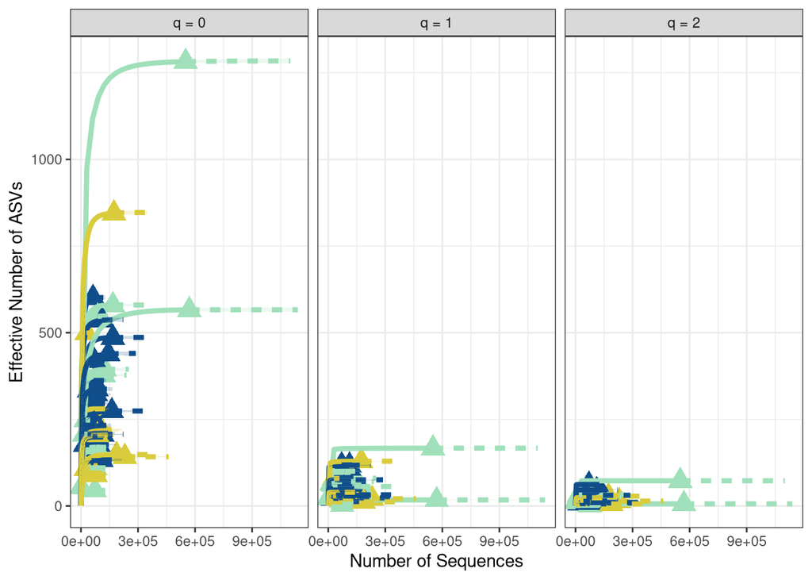

```r
ggiNEXT(iNEXT_data, type = 1, facet.var = "Order.q") +
  scale_color_manual(values = iNEXT_color_df$AgeRange_colors) +
  scale_fill_manual(values = iNEXT_color_df$AgeRange_colors) +
  scale_shape_manual(values = base::rep(17, nsamples(midpoint_rooted_physeq))) +
  theme_bw() +
  theme(legend.position = "none") +
  labs(y = "Effective Number of ASVs", x = "Number of Sequences")
```

Remembering that an Order q of:

- 0 = Richness/ Number of Total taxa
- 1 = Exponential Shannon / Number of “Common” taxa
- 2 = Inverse Simpson / Number of “Dominant” taxa

*Also note that iNEXT will extrapolate the number of sequences to double the sequencing depth of the sample!* This extrapolation is represented by the dotted line, which extends to 2 x the library size of the sample.

Let’s draw some conclusions from the plot above:

1. The best gift of the Hill Numbers: *All three diversity measures are on the same x-axis: The Effective Number of Species or ASVs.*
2. As q increases from 0 to 1 to 2, the abundance of the species is weighted more, so the rarefaction curve plateaus earlier. This is important because it **indicates that richness is the most sensitive to sequencing depth!** However, Shannon and even less sensitive is Simpson.
3. Most of the sample rarefaction curves appear to plateau but we need to look deeper to truly confirm this.

Let’s manually plot the data that we pull out from the iNEXT data.

## Manual Rarefaction Curves

```r
str(iNEXT_data)
```

```
## List of 3
##  $ DataInfo:'data.frame':    44 obs. of  14 variables:
##   ..$ Assemblage: chr [1:44] "X16S0064C" "X16S0064W" "X16S0073C" "X16S0073O" ...
##   ..$ n         : num [1:44] 66771 63163 107267 73242 29488 ...
##   ..$ S.obs     : num [1:44] 362 601 220 280 499 142 216 110 580 177 ...
##   ..$ SC        : num [1:44] 1 1 1 1 1 ...
##   ..$ f1        : num [1:44] 2 3 1 1 2 0 2 0 0 0 ...
##   ..$ f2        : num [1:44] 8 14 2 2 24 2 2 2 8 0 ...
##   ..$ f3        : num [1:44] 18 37 5 6 28 5 2 4 11 6 ...
##   ..$ f4        : num [1:44] 11 30 4 4 26 4 7 1 21 3 ...
##   ..$ f5        : num [1:44] 14 36 5 7 45 2 4 4 13 2 ...
##   ..$ f6        : num [1:44] 11 37 2 1 31 0 5 3 9 4 ...
##   ..$ f7        : num [1:44] 10 26 5 5 28 3 4 7 16 1 ...
##   ..$ f8        : num [1:44] 11 30 8 6 25 1 6 3 15 3 ...
##   ..$ f9        : num [1:44] 15 34 5 4 22 2 6 2 14 0 ...
##   ..$ f10       : num [1:44] 12 18 7 5 12 7 5 3 11 3 ...
##  $ iNextEst:List of 2
##   ..$ size_based    :'data.frame':   5280 obs. of  10 variables:
##   .. ..$ Assemblage: chr [1:5280] "X16S0064C" "X16S0064C" "X16S0064C" "X16S0064C" ...
##   .. ..$ m         : num [1:5280] 1 3710 7419 11129 14838 ...
##   .. ..$ Method    : chr [1:5280] "Rarefaction" "Rarefaction" "Rarefaction" "Rarefaction" ...
##   .. ..$ Order.q   : num [1:5280] 0 0 0 0 0 0 0 0 0 0 ...
##   .. ..$ qD        : num [1:5280] 1 243 291 315 329 ...
##   .. ..$ qD.LCL    : num [1:5280] 1 240 288 312 326 ...
##   .. ..$ qD.UCL    : num [1:5280] 1 245 294 318 332 ...
##   .. ..$ SC        : num [1:5280] 0.0543 0.9803 0.9914 0.9951 0.9969 ...
##   .. ..$ SC.LCL    : num [1:5280] 0.0535 0.9799 0.9912 0.995 0.9968 ...
##   .. ..$ SC.UCL    : num [1:5280] 0.055 0.981 0.992 0.995 0.997 ...
##   ..$ coverage_based:'data.frame':   4263 obs. of  8 variables:
##   .. ..$ Assemblage: chr [1:4263] "X16S0064C" "X16S0064C" "X16S0064C" "X16S0064C" ...
##   .. ..$ SC        : num [1:4263] 0.0543 0.9803 0.9914 0.9951 0.9969 ...
##   .. ..$ m         : num [1:4263] 1 3710 7419 11129 14838 ...
##   .. ..$ Method    : chr [1:4263] "Rarefaction" "Rarefaction" "Rarefaction" "Rarefaction" ...
##   .. ..$ Order.q   : num [1:4263] 0 0 0 0 0 0 0 0 0 0 ...
##   .. ..$ qD        : num [1:4263] 1 243 291 315 329 ...
##   .. ..$ qD.LCL    : num [1:4263] 0.99 239.05 287.14 311.42 326.03 ...
##   .. ..$ qD.UCL    : num [1:4263] 1.01 246.32 294.28 318.05 332.2 ...
##  $ AsyEst  :'data.frame':    132 obs. of  7 variables:
##   ..$ Assemblage: chr [1:132] "X16S0064C" "X16S0064C" "X16S0064C" "X16S0064W" ...
##   ..$ Diversity : chr [1:132] "Species richness" "Shannon diversity" "Simpson diversity" "Species richness" ...
##   ..$ Observed  : num [1:132] 362 47.4 18.4 601 31.6 ...
##   ..$ Estimator : num [1:132] 362.2 47.5 18.4 601.3 31.8 ...
##   ..$ s.e.      : num [1:132] 2.871 0.324 0.127 3.659 0.347 ...
##   ..$ LCL       : num [1:132] 362 46.9 18.2 601 31.1 ...
##   ..$ UCL       : num [1:132] 367.9 48.1 18.7 608.5 32.5 ...
##  - attr(*, "class")= chr "iNEXT"
```

```r
iNEXT_manual_df <-
  iNEXT_data$iNextEst$size_based %>%
  dplyr::rename(names = Assemblage) %>%
  # fix the samples to merge with metadata
  mutate(names = gsub(names, pattern = "X", replace = "")) %>%
  # join with the metadata
  left_join(., metadata_df, by = "names") %>%
  mutate(AgeRange = factor(AgeRange, levels = c("JUVENILE",
                                              "SUB-ADULT",
                                              "ADULT")))

# Inspection
dim(iNEXT_manual_df)
```

```
## [1] 5280   47
```

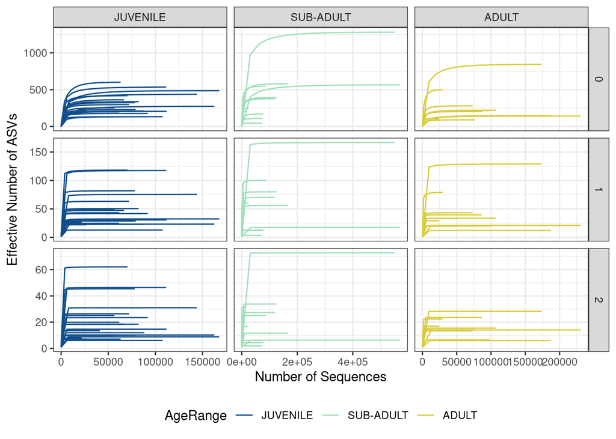

```r
# Manually plot rarefaction curves
iNEXT_manual_df %>%
  # Filter out rows that are calculated with actual sequences (no extrapolated)
  dplyr::filter(Method == "Rarefaction") %>%
  # Now, let's draw the plot!
  ggplot(aes(x = m, y = qD, color = AgeRange, group = names)) +
  geom_line() +
  # Facet by station
  facet_grid(Order.q~AgeRange, scales = "free") +
  scale_color_manual(values = AgeRange_colors) +
  theme_bw() +
  labs(y = "Effective Number of ASVs", x = "Number of Sequences") +
  theme(legend.position = "bottom")
```

Interpretation 1: There are more juvenile turtles than sub-adult or adult turtles. These turtles are endangered so maybe they are dying at younger ages than normal. It’s a little bit hard to tell but it looks like all curved asymptote (some just barely in the sub-adults), indicating there are enough sequences to analyze the samples.

- *Richness: q = 0*
  - All the samples with **richness plateau! (JUST barely with some sub-adults) This is essential and determines whether or not we can make conclusions about the observed richness!** If the richness values do not plateau, then we cannot make any assertions regarding the ASV richness in the samples because the samples have not been sequenced deeply enough to measure this. Instead, we *might* be able to rely on the extrapolated values, however, this will require a lot of caution.
  - I think my two outliers from processing this data are from a sub-adult and an adult.
  - Excluding outliers, adults may have less total richness, and juveniles and sub-adults may have roughly the same richness.
- *Shannon Diversity: q = 1*
  - There doesn’t seem to be much of a difference between age groups.
- *Simpson’s Diversity: q = 2*
  - The adult outlier fits much better with the data here, but the sub-adult outlier is still outlier-ing.
  - Excluding the outlier, sub-adults and adults may have less ASVs than junveniles, even though this is not what I was expecting.

# Statististical Testing

So, how do we actually quantify the changes in biodiversity that we may observe between the samples? That takes us into statistics!

## Parametric vs. Non-Parametric Statistics??

| Feature | Parametric | Non-Parametric |
| --- | --- | --- |
| **Assumptions** | Assumes a known distribution (usually normal) | Fewer assumptions about distribution |
| **Data Type** | Continuous (interval/ratio) | Ordinal or non-normal continuous |
| **Examples** | t-test, ANOVA, linear regression | Wilcoxon, Kruskal-Wallis, Spearman |
| **Estimates Based On** | Parameters like mean and variance | Ranks or medians |
| **Sensitive to Outliers?** | Yes | Less sensitive |
| **Statistical Power** | Higher if assumptions are met | Lower but more robust to violations |

### Parametric Statistics

Parametric tests assume that the data follow a specific distribution (usually a normal/Gaussian distribution). They are more statistically powerful **if those assumptions are met**. Some examples include, comparing means with a t-test or ANOVA or modeling relationships using linear regression.

### Non-Parametric Statistics

- Data are skewed or non-normal
- Sample sizes are small
- Outliers are present
- You’re analyzing ranks (*e.g.,* ordinal data) or medians

## How do I test if my data is “normal”?

Typically people perform a **Shapiro-Wilk Test** on their data. The Shapiro-Wilk test is a statistical test used to check whether a sample of data comes from a normally distributed population.

The Shapiro-Wilk test calculates a **W statistic** by comparing the order statistics (sorted values) of your data with those expected from a normal distribution.

- **W ≈ 1** → data is close to normal.
- **W < 1** → increasing deviation from normality.

What hypothses does the Shapiro-Wilk Test?

- *Null hypothesis (H₀):* The data are normally distributed.
  - *p-value > 0.05*: Fail to reject H₀ and the data appears normal.
- *Alternative hypothesis (H₁):* The data are *not* normally distributed.
  - *p-value < 0.05*: We can reject the H₀, which will indicate that the data is **not normal**.

**How to run the Shapiro-Wilk test?**

*Run Shapiro-Wilk for Weight*

```r
# Test of the data is normal for the continuous value of weight
shapiro.test(metadata_df$Weight)
```

```
##
##  Shapiro-Wilk normality test
##
## data:  metadata_df$Weight
## W = 0.90201, p-value = 0.001255
```

The p value is < 0.05, indicating that we can reject the H₀, which will indicate that the data is **not normal**. Therefore, we need to use non-parametric statistical tests in the data.

However, I want to look at Age, which is only designated by **JUVENILE**, **SUB-ADULT**, and **ADULT**.

*Is the richness data normal?*

```r
### Now what about for richness?
obs_div_df <-
  iNEXT_manual_df %>%
  dplyr::filter(Method == "Observed")

# check it
glimpse(obs_div_df)
```

```
## Rows: 132
## Columns: 47
## $ names                             <chr> "16S0064C", "16S0064C", "16S0064C", …
## $ m                                 <dbl> 66771, 66771, 66771, 63163, 63163, 6…
## $ Method                            <chr> "Observed", "Observed", "Observed", …
## $ Order.q                           <dbl> 0, 1, 2, 0, 1, 2, 0, 1, 2, 0, 1, 2, …
## $ qD                                <dbl> 362.000000, 47.377156, 18.425124, 60…
## $ qD.LCL                            <dbl> 359.366262, 46.732192, 18.165297, 59…
## $ qD.UCL                            <dbl> 364.633738, 48.022119, 18.684952, 60…
## $ SC                                <dbl> 0.9999701, 0.9999701, 0.9999701, 0.9…
## $ SC.LCL                            <dbl> 0.9998940, 0.9998940, 0.9998940, 0.9…
## $ SC.UCL                            <dbl> 1, 1, 1, 1, 1, 1, 1, 1, 1, 1, 1, 1, …
## $ TBSampleID                        <chr> "SC0064", "SC0064", "SC0064", "FW006…
## $ SamplingEvent                     <chr> "PMFTI0064", "PMFTI0064", "PMFTI0064…
## $ TurtleID                          <chr> "ID047", "ID047", "ID047", "ID047", …
```

[output cut: 34 more lines]

```r
# Pull out richness
obs_whole_rich_df <-
  obs_div_df %>%
  dplyr::filter(Order.q == 0)

# Test of the data is normal for the continuous value of richness
shapiro.test(obs_whole_rich_df$qD)
```

```
##
##  Shapiro-Wilk normality test
##
## data:  obs_whole_rich_df$qD
## W = 0.81441, p-value = 6.105e-06
```

**No, the diversity data is NOT normal.** This means we must use nonparamentric tests.

## Statistics in Microbial Ecology

Generally speaking, we tend to use non-parametric tests in microbial ecology. It’s safer to go this way. However, if there is a test performed to show that the data is normally distributed, then we can access the robustness of parametric tests!

| **Research Question** | **Parametric Test** | **Non-Parametric Test** |
| --- | --- | --- |
| Compare alpha diversity (2 groups) | t-test | Wilcoxon rank-sum test |
| Compare alpha diversity (more than 2 groups) | ANOVA | Kruskal-Wallis test |
| Correlate diversity with environmental data | Pearson correlation | Spearman correlation |
| Test differences in beta diversity | *Not applicable* (uses distance matrices) | PERMANOVA (non-parametric) |
| Model transformed taxon abundances | Linear regression, GLM | Rank-based regression |

**Takeaways about statistics**

- **Parametric statistics** use data values directly (means, variances) and are more powerful when assumptions (*e.g.,* normality, homoscedasticity) are met.
- **Non-parametric statistics** use ranks and are more powerful when there are violations of assumptions that are made in parametric statistics, making them a safer choice for skewed, sparse, or ordinal data, which is commonplace in microbial ecology.
- In microbial ecology, non-parametric methods are commonly used due to the nature of microbiome data (*e.g.,* zero-inflated, non-normal, compositional), but **parametric tests are absolutely valid** when assumptions are met or appropriate transformations are applied.

Choose your statistical approach based on the:

- Type and distribution of your data
- Question you’re asking
- Assumptions your data can reasonably meet

# Categorical Analysis: 2 or more groups

## Diversity by Age Group

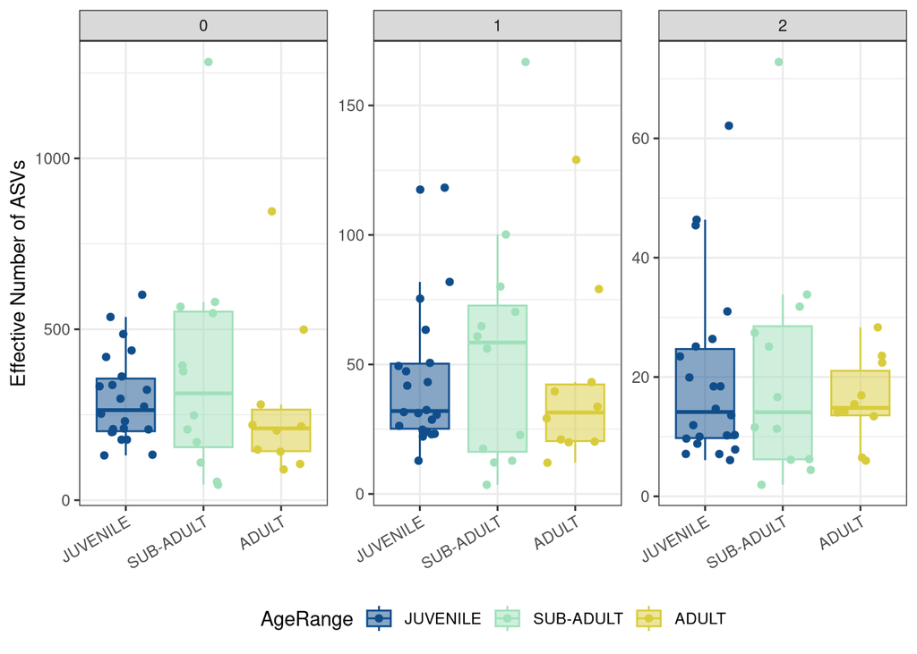

```r
# Plot boxplots by Age Group against diversity
obs_div_df %>%
  ggplot(aes(x = AgeRange, y = qD, fill = AgeRange,
             color = AgeRange)) +
  facet_wrap(.~Order.q, scales = "free_y") +
  geom_jitter() +
  geom_boxplot(alpha = 0.5, outlier.shape = NA) +
  scale_color_manual(values = AgeRange_colors) +
  scale_fill_manual(values = AgeRange_colors) +
  labs(y = "Effective Number of ASVs") +
  theme_bw() +
  theme(legend.position = "bottom",
        axis.title.x = element_blank(),
        axis.text.x = element_text(angle = 30,
                                   hjust = 1,
                                   vjust = 1))
```

#### Statistically test Richness

```r
# Pull out richness data
obs_rich_df <-
  obs_div_df %>%
  dplyr::filter(Order.q == 0)

# Calculate the Kruskal-Wallis bc data is not normal
kruskal_age_rich <-
  obs_rich_df %>%
  kruskal_test(qD ~ AgeRange)

# Look at it
kruskal_age_rich
```

```
## # A tibble: 1 × 6
##   .y.       n statistic    df     p method
## * <chr> <int>     <dbl> <int> <dbl> <chr>
## 1 qD       44      1.20     2 0.549 Kruskal-Wallis
```

```r
summary(kruskal_age_rich)
```

```
##      .y.                  n        statistic           df          p
##  Length:1           Min.   :44   Min.   :1.199   Min.   :2   Min.   :0.549
##  Class :character   1st Qu.:44   1st Qu.:1.199   1st Qu.:2   1st Qu.:0.549
##  Mode  :character   Median :44   Median :1.199   Median :2   Median :0.549
##                     Mean   :44   Mean   :1.199   Mean   :2   Mean   :0.549
##                     3rd Qu.:44   3rd Qu.:1.199   3rd Qu.:2   3rd Qu.:0.549
##                     Max.   :44   Max.   :1.199   Max.   :2   Max.   :0.549
##     method
##  Length:1
##  Class :character
##  Mode  :character
##
##
##
```

```r
# post-hoc test with Dunn's Test
dunn_age_richness <-
  obs_rich_df %>%
  dunn_test(qD ~ AgeRange, p.adjust.method = "fdr") %>%
  add_xy_position(x = "AgeRange")

# look at the pairwise
dunn_age_richness
```

```
## # A tibble: 3 × 13
##   .y.   group1  group2    n1    n2 statistic     p p.adj p.adj.signif y.position
##   <chr> <chr>   <chr>  <int> <int>     <dbl> <dbl> <dbl> <chr>             <dbl>
## 1 qD    JUVENI… SUB-A…    22    12    0.0764 0.939 0.939 ns                1364.
## 2 qD    JUVENI… ADULT     22    10   -1.00   0.315 0.506 ns                1486.
## 3 qD    SUB-AD… ADULT     12    10   -0.959  0.337 0.506 ns                1609.
## # ℹ 3 more variables: groups <named list>, xmin <dbl>, xmax <dbl>
```

```r
# Richness by Age Group
AgeGroup_ggboxplot <-
  ggboxplot(obs_rich_df, x = "AgeRange", y = "qD",
          color = "AgeRange", fill = "AgeRange", alpha = 0.3,
          outlier.shape = NA) +
  # Add points
  geom_jitter(aes(color = AgeRange)) +
  scale_color_manual(values = AgeRange_colors) +
  scale_fill_manual(values = AgeRange_colors) +
  labs(y = "# Total ASVs (Richness)") +
  # Now, let's add the KW results
  stat_pvalue_manual(dunn_age_richness, hide.ns = TRUE,
                      tip.length = 0, step.increase = 0.01) +
  labs(subtitle = get_test_label(kruskal_age_rich, detailed = TRUE),
       caption = get_pwc_label(dunn_age_richness)) +
  theme_bw() +
  theme(legend.position = "none",
        axis.title.x = element_blank(),
        axis.text.x = element_text(angle = 30,
                                   hjust = 1,
                                   vjust = 1))
```

### Simpson

```r
# Pull out simpson data
obs_simps_df <-
  obs_div_df %>%
  dplyr::filter(Order.q == 2)

# Calculate the Kruskal-Wallis
kruskal_age_simps <-
  obs_simps_df %>%
  kruskal_test(qD ~ AgeRange)

# Look at it
kruskal_age_simps
```

```
## # A tibble: 1 × 6
##   .y.       n statistic    df     p method
## * <chr> <int>     <dbl> <int> <dbl> <chr>
## 1 qD       44    0.0554     2 0.973 Kruskal-Wallis
```

```r
# post-hoc test with Dunn's Test
dunn_age_simps <-
  obs_simps_df %>%
  dunn_test(qD ~ AgeRange, p.adjust.method = "fdr") %>%
  add_xy_position(x = "AgeRange")

# look at the pairwise
dunn_age_simps
```

```
## # A tibble: 3 × 13
##   .y.   group1  group2    n1    n2 statistic     p p.adj p.adj.signif y.position
##   <chr> <chr>   <chr>  <int> <int>     <dbl> <dbl> <dbl> <chr>             <dbl>
## 1 qD    JUVENI… SUB-A…    22    12   -0.207  0.836 0.985 ns                 78.1
## 2 qD    JUVENI… ADULT     22    10   -0.174  0.862 0.985 ns                 86.1
## 3 qD    SUB-AD… ADULT     12    10    0.0182 0.985 0.985 ns                 94.1
## # ℹ 3 more variables: groups <named list>, xmin <dbl>, xmax <dbl>
```

```r
# Simpson by Age Group
simps_ggboxplot <-
  ggboxplot(obs_simps_df, x = "AgeRange", y = "qD",
          color = "AgeRange", fill = "AgeRange", alpha = 0.3,
          outlier.shape = NA) +
  # Add points
  geom_jitter(aes(color = AgeRange)) +
  scale_color_manual(values = AgeRange_colors) +
  scale_fill_manual(values = AgeRange_colors) +
  labs(y = "# Dominant ASVs (Simpson)") +
  # Now, let's add the KW results
  stat_pvalue_manual(dunn_age_simps, hide.ns = TRUE,
                      tip.length = 0, step.increase = 0.01) +
  labs(subtitle = get_test_label(kruskal_age_simps, detailed = TRUE),
       caption = get_pwc_label(dunn_age_simps)) +
  theme_bw() +
  theme(legend.position = "none",
        axis.title.x = element_blank(),
        axis.text.x = element_text(angle = 30,
                                   hjust = 1,
                                   vjust = 1))
```

### Shannon

```r
# Pull out simpson data
obs_shan_df <-
  obs_div_df %>%
  dplyr::filter(Order.q == 1)

# Calculate the Kruskal-Wallis
kruskal_age_shan <-
  obs_shan_df %>%
  kruskal_test(qD ~ AgeRange)

# Look at it
kruskal_age_shan
```

```
## # A tibble: 1 × 6
##   .y.       n statistic    df     p method
## * <chr> <int>     <dbl> <int> <dbl> <chr>
## 1 qD       44     0.616     2 0.735 Kruskal-Wallis
```

```r
# post-hoc test with Dunn's Test
dunn_age_shan <-
  obs_shan_df %>%
  dunn_test(qD ~ AgeRange, p.adjust.method = "fdr") %>%
  add_xy_position(x = "AgeRange")

# look at the pairwise
dunn_age_shan
```

```
## # A tibble: 3 × 13
##   .y.   group1  group2    n1    n2 statistic     p p.adj p.adj.signif y.position
##   <chr> <chr>   <chr>  <int> <int>     <dbl> <dbl> <dbl> <chr>             <dbl>
## 1 qD    JUVENI… SUB-A…    22    12   -0.0247 0.980 0.980 ns                 173.
## 2 qD    JUVENI… ADULT     22    10   -0.748  0.455 0.778 ns                 181.
## 3 qD    SUB-AD… ADULT     12    10   -0.645  0.519 0.778 ns                 190.
## # ℹ 3 more variables: groups <named list>, xmin <dbl>, xmax <dbl>
```

[figure not shown]

```r
# Simpson by Age Group
shan_ggboxplot <-
  ggboxplot(obs_simps_df, x = "AgeRange", y = "qD",
          color = "AgeRange", fill = "AgeRange", alpha = 0.3,
          outlier.shape = NA) +
  # Add points
  geom_jitter(aes(color = AgeRange)) +
  scale_color_manual(values = AgeRange_colors) +
  scale_fill_manual(values = AgeRange_colors) +
  labs(y = "# Common ASVs (Shannon)") +
  # Now, let's add the KW results
  stat_pvalue_manual(dunn_age_shan, hide.ns = TRUE,
                      tip.length = 0, step.increase = 0.01) +
  labs(subtitle = get_test_label(kruskal_age_shan, detailed = TRUE),
       caption = get_pwc_label(dunn_age_shan)) +
  theme_bw() +
  theme(legend.position = "none",
        axis.title.x = element_blank(),
        axis.text.x = element_text(angle = 30,
                                   hjust = 1,
                                   vjust = 1))

# Show the plot
AgeGroup_ggboxplot + shan_ggboxplot + simps_ggboxplot
```

Interpretation 2: It looks like ASVs (all, common, and dominant) do not differ between Loggerhead sea turtles of different age groups (junevile, sub-adult, and adult).

Interpretation 3: I used a Kruskal-Wallis statistal test followed by Dunn’s test because my data is not normal.

# Continuous Relationships - Weight vs Biodiversity

## Spearman vs. Linear Model: What’s the Difference?

| Feature | **Spearman Correlation** | **Linear Model (`lm()`)** |
| --- | --- | --- |
| **Type of Relationship** | Monotonic (increasing or decreasing) | Linear (straight-line relationship) |
| **Assumptions** | Non-parametric (no distribution assumptions) | Parametric (normality, linearity, homoscedasticity) |
| **Input Data** | Ordinal, ranked, or continuous | Continuous (can include categorical predictors too) |
| **What it Measures** | Strength and direction of monotonic relationship | Effect size, direction, significance of predictors |
| **Output** | Correlation coefficient (ρ) and p-value | Intercept, slope(s), p-values, R², residuals, etc. |
| **Resistant to Outliers?** | More robust | Sensitive to outliers |
| **Function in R** | `cor.test(x, y, method = "spearman")` | `lm(y ~ x)` |

## Continuous Variable—Weight (kg)

- *Juvenile* turtles had a median weight of 8 kg
- *Subadult* turtles had a median weight of 31.6 kg
- *Adult* turtles had a median weight of 50.8 kg

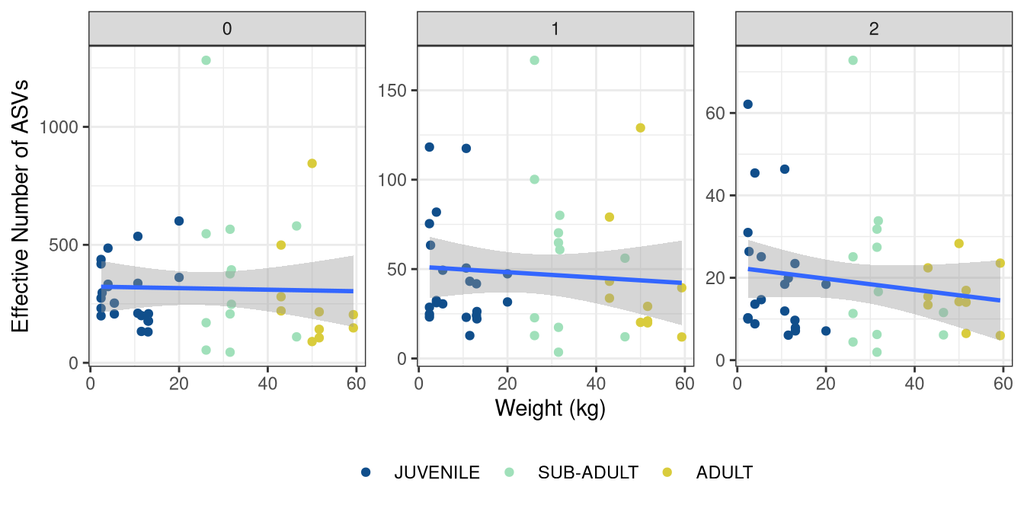

```r
# How does biodiversity change over age group?
obs_div_df %>%
  ggplot(aes(x = Weight, y = qD)) +
  facet_wrap(.~Order.q, scales = "free") +
  geom_point(aes(color = AgeRange)) +
  scale_color_manual(values = AgeRange_colors) +
  labs(x = "Weight (kg)", y = "Effective Number of ASVs") +
  geom_smooth(method = "lm") +
  theme_bw() +
  theme(legend.position = "bottom",
        legend.title = element_blank())
```

### Explore Richness More

```r
# Make a richness data frame
richness_df <-
  obs_div_df %>%
  dplyr::filter(Order.q == 0)

# Actually run the linear model
rich_vs_weight_lm <-
  lm(qD ~ Weight, data = richness_df)

# Show me the model results
rich_vs_weight_lm
```

```
##
## Call:
## lm(formula = qD ~ Weight, data = richness_df)
##
## Coefficients:
## (Intercept)       Weight
##    323.1463      -0.3319
```

```r
# Type?
class(rich_vs_weight_lm)
```

```
## [1] "lm"
```

```r
# Summary of lm
summary(rich_vs_weight_lm)
```

```
##
## Call:
## lm(formula = qD ~ Weight, data = richness_df)
##
## Residuals:
##     Min      1Q  Median      3Q     Max
## -267.69 -141.81  -78.62   85.22  967.52
##
## Coefficients:
##             Estimate Std. Error t value Pr(>|t|)
## (Intercept) 323.1463    57.8977   5.581 1.59e-06 ***
## Weight       -0.3319     1.9004  -0.175    0.862
## ---
## Signif. codes:  0 '***' 0.001 '**' 0.01 '*' 0.05 '.' 0.1 ' ' 1
##
## Residual standard error: 229.8 on 42 degrees of freedom
## Multiple R-squared:  0.0007255,  Adjusted R-squared:  -0.02307
## F-statistic: 0.03049 on 1 and 42 DF,  p-value: 0.8622
```

In the output:

- **Coefficients** refer to the 𝛽’s
- **Estimate** is the estimate of each coefficient
- **Std. Error** is the standard error of the estimate
- **t value** is the coefficient divided by its standard error
- **Pr(>|t|)** is the p-value for the coefficient
- The **residual standard error** is the estimate of the variance of 𝜖
- **Degrees of freedom** is the sample size minus # of coefficients estimated
- **R-squared** is (roughly) the proportion of variance in the outcome explained by the model, instead we should always report the **adjusted R-squared**, which takes into penalizes the addition of unnecessary predictors, which provides a more accurate measure of model fit.
  - Note that the R-squared value will always increase/stay the same when you add more predictors, even if they are not relevant!
- The **F-statistic** compares the fit of the model as a whole to the null model (with no covariates)
  - When comparing models, we always want to take the model with the higher F-statistic because it indicates a stronger relationship between the predictor varaibles and the dependent variables, suggesting that the model is better.

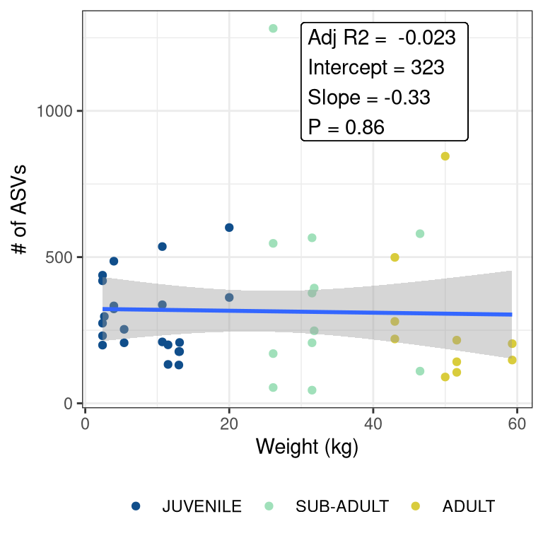

```r
richness_df %>%
  ggplot(aes(x = Weight, y = qD)) +
  geom_point(aes(color = AgeRange)) +
  stat_smooth(method = "lm") +
  labs(x = "Weight (kg)", y = "# of ASVs") +
  scale_color_manual(values = AgeRange_colors) +
  theme_bw() +
  theme(legend.position = "bottom",
        legend.title = element_blank()) +
  geom_label(aes(x = 30, y = 1100), hjust = 0,
             label = paste("Adj R2 = ",signif(summary(rich_vs_weight_lm)$adj.r.squared, 2),
                           "\nIntercept =",signif(rich_vs_weight_lm$coef[[1]],3),
                           " \nSlope =",signif(rich_vs_weight_lm$coef[[2]], 2),
                           " \nP =",signif(summary(rich_vs_weight_lm)$coef[2,4], 2)))
```

## Spearman Correlation

```r
rich_weight_plot <-
  richness_df %>%
  ggplot(aes(x = Weight, y = qD)) +
  geom_point(aes(color = AgeRange)) +
  stat_smooth(method = "lm") +
  labs(x = "Weight (kg)", y = "# of Total ASVs (Richness)") +
  scale_color_manual(values = AgeRange_colors) +
  theme_bw() +
  theme(legend.position = "bottom",
        legend.title = element_blank()) +
  stat_cor(method = "spearman", label.x = 3, label.y = 1000)  # customize label position
```

```r
simps_df <-
  obs_div_df %>%
  dplyr::filter(Order.q == 2)

simps_weight_plot <-
  simps_df %>%
  ggplot(aes(x = Weight, y = qD)) +
  geom_point(aes(color = AgeRange)) +
  stat_smooth(method = "lm") +
  labs(x = "Weight (kg)", y = "# of Dominant ASVs (Simpson)") +
  scale_color_manual(values = AgeRange_colors) +
  theme_bw() +
  theme(legend.position = "bottom",
        legend.title = element_blank()) +
  stat_cor(method = "spearman", label.x = 10, label.y = 60)  # customize label position
```

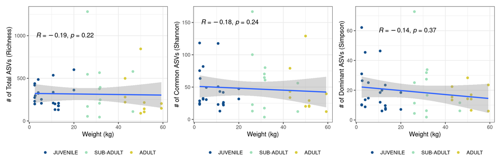

```r
shan_df <-
  obs_div_df %>%
  dplyr::filter(Order.q == 1)

shan_weight_plot <-
  shan_df %>%
  ggplot(aes(x = Weight, y = qD)) +
  geom_point(aes(color = AgeRange)) +
  stat_smooth(method = "lm") +
  labs(x = "Weight (kg)", y = "# of Common ASVs (Shannon)") +
  scale_color_manual(values = AgeRange_colors) +
  theme_bw() +
  theme(legend.position = "bottom",
        legend.title = element_blank()) +
  stat_cor(method = "spearman", label.x = 3, label.y = 150)  # customize label position

#Plot!
rich_weight_plot + shan_weight_plot + simps_weight_plot
```

Null: There is no correlation between the variables - Rho slightly less than 0: Weak negative correlation. - p-value > 0.05: no significant correlation.

Interpretation 4: It looks like ASVs (all, common, and dominant) do not differ between Loggerhead sea turtles of different weights.

Interpretation 5: I used Spearman correlations to test my data because my data is not normal.

# Final info for Reproducibility

## Check Render Time

```r
# Take the time now that we are at the end of the script
end_time <- Sys.time()
end_time
```

```
## [1] "2025-04-11 11:34:45 EDT"
```

```r
# Echo the elapsed time
elapsed_time <- round((end_time - start_time), 3)
elapsed_time
```

```
## Time difference of 11.805 secs
```